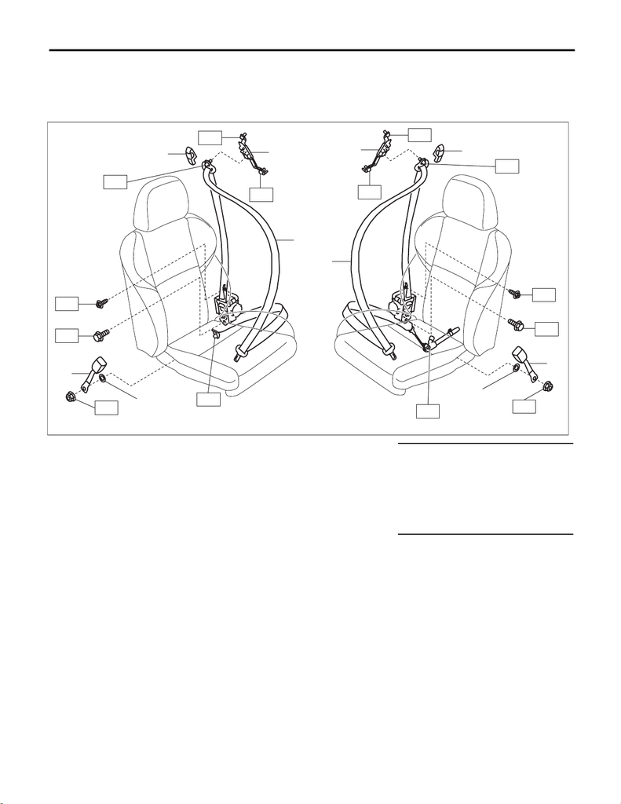

General Description

SEAT BELT SYSTEM

1. General Description

A: COMPONENT

1. FRONT SEAT BELT

(1) Adjuster ASSY - seat belt (4) Wave washer Tightening torque: N·m (kgf-m, ft-lb)

(2) Cover through (5) Seat belt outer - front T1: 7.5 (0.8, 5.5)

(3) Seat belt inner - front (6) Seat belt outer - front (only on

passenger’s side with lap seat belt

pretensioner)

T2: 30 (3.1, 22.1)

T3: 38 (3.9, 28.0)

T4: 53 (5.4, 39.1)

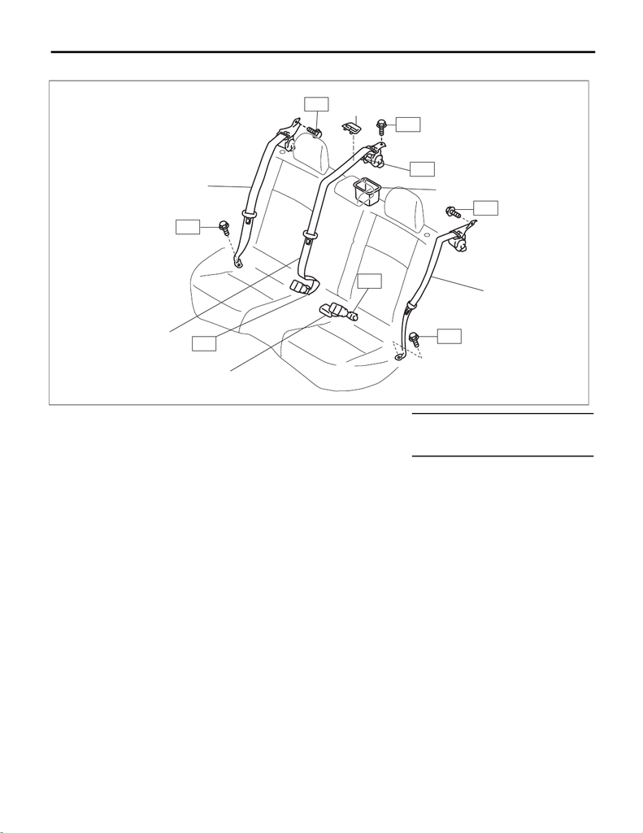

2. REAR SEAT BELT

(1) Seat belt outer - rear RH (4) Seat belt outer - rear LH Tightening torque: N·m (kgf-m, ft-lb)

(2) Seat belt - rear shoulder CTR (5) Cover - ELR T1: 30 (3.1, 22.1)

(3) Seat belt - CTR LH (6) Cover - belt rear T2: 53 (5.4, 39.1)

[figure not shown]

B: CAUTION

• Before starting the work, turn the ignition switch to OFF, disconnect the battery ground cable and wait for

60 seconds or more.

• The airbag system (including pretensioner) is fitted with a backup power supply. After disconnecting the

battery ground cable, the airbag may operate if you do not wait for 60 seconds or more before starting the

service of airbag system.

• Do not drop or apply any impact to the pretensioner.

• If oil, grease or water gets on the pretensioner, wipe it off immediately with a dry cloth.

• Do not expose the pretensioner to high temperature or flame.

• Do not allow current to flow through or voltage to reach the pretensioner. Do not use a circuit tester to

check resistance of the pretensioner.

• Do not disassemble or attempt to repair the pretensioner. If it is dented, cracked or deformed, replace it

with a new genuine part.

• Do not use the airbag or pretensioner parts from other vehicles. Always use a new genuine part for re-

placement.

• When handling a seat belt with deployed pretensioner, wear gloves and goggles. Wash your hands after-

wards.

• Do not reuse a seat belt with deployed pretensioner.

• Before disposal, make sure to perform an operation process to the pretensioners.

• If material from the pretensioner enters the eyes or contacts skin during operation process, wash it away

with clean water, and then consult a doctor.

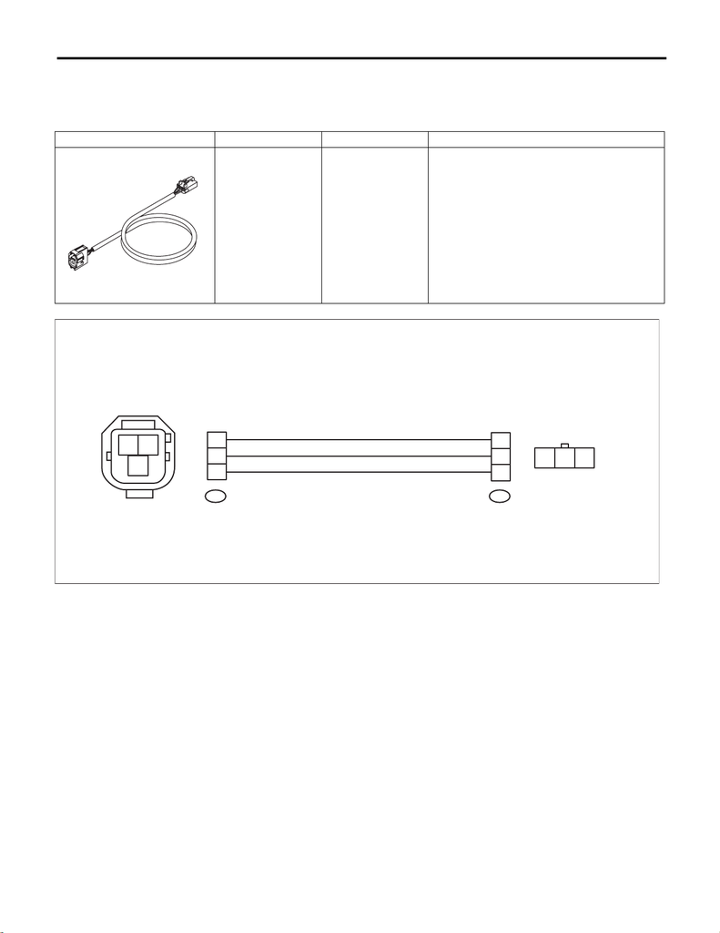

C: PREPARATION TOOL

1. SPECIAL TOOL

• TEST HARNESS AP

ILLUSTRATION TOOL NUMBER DESCRIPTION REMARKS

98299FJ030 TEST HARNESS

AP

Used when measuring voltage and resistance of

occupant detection system.

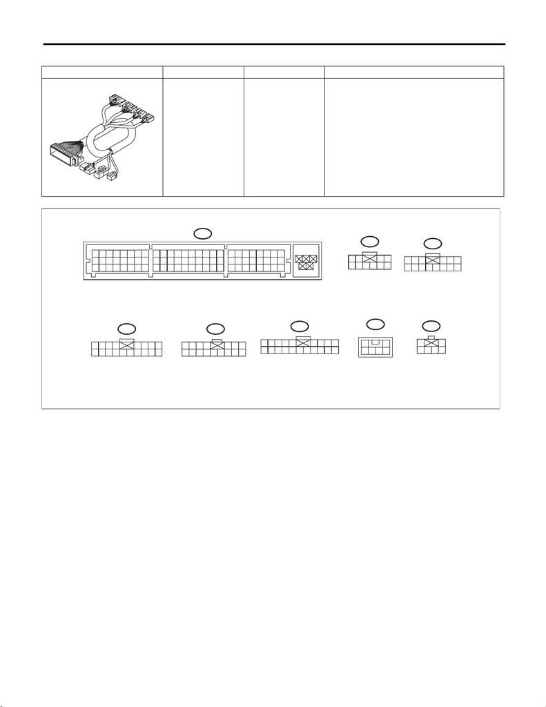

• TEST HARNESS AG

ILLUSTRATION TOOL NUMBER DESCRIPTION REMARKS

98299AG070 TEST HARNESS

AG

Used when measuring voltage and resistance of

airbag control module.

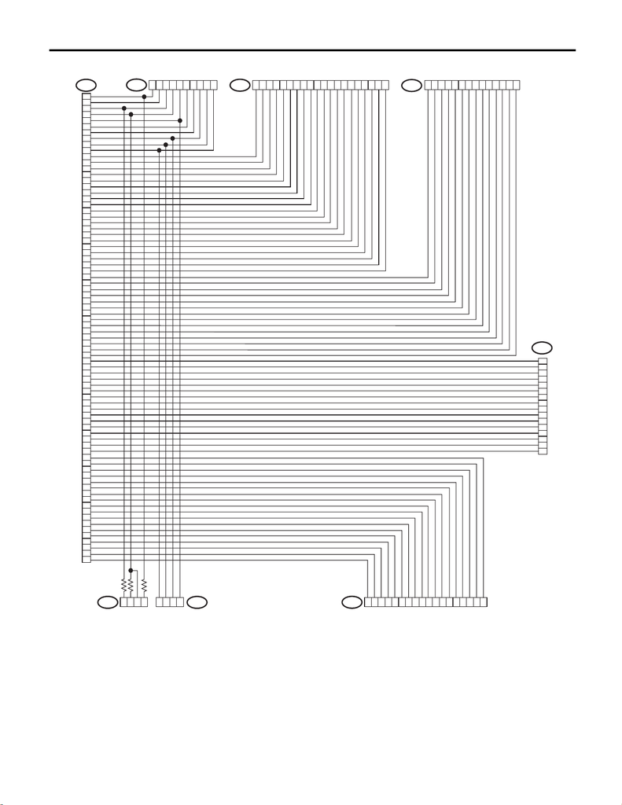

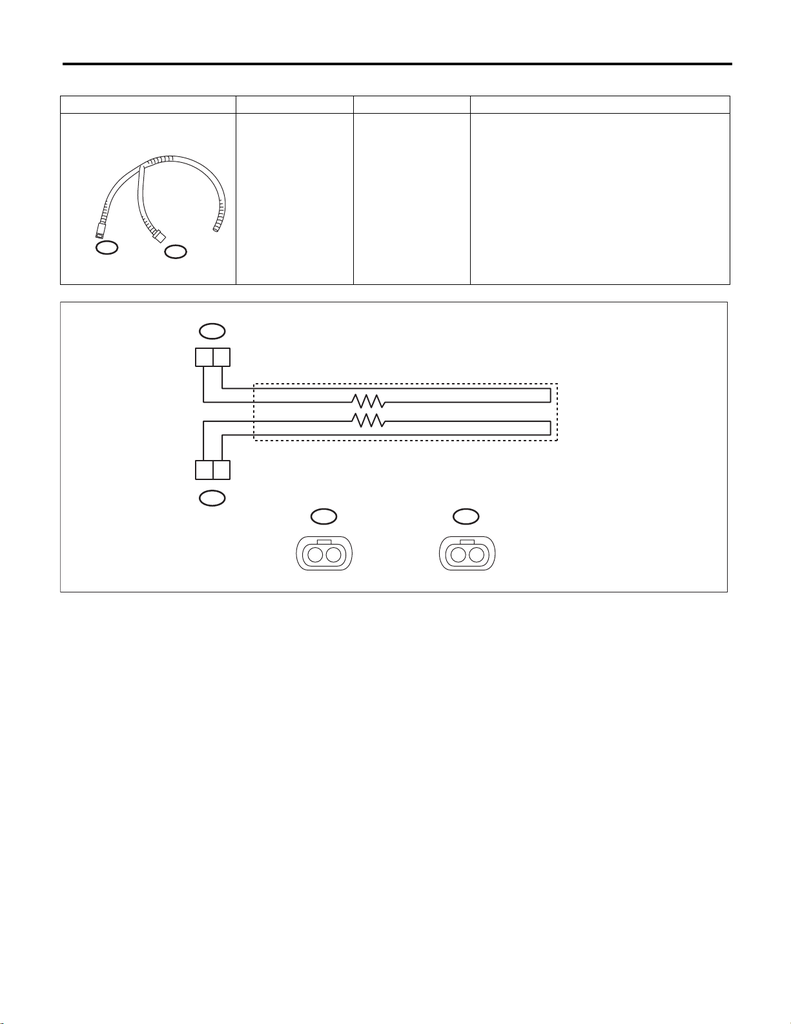

• TEST HARNESS Y

ILLUSTRATION TOOL NUMBER DESCRIPTION REMARKS

98299AG040 TEST HARNESS Y Used for troubleshooting seat belt buckle switch.

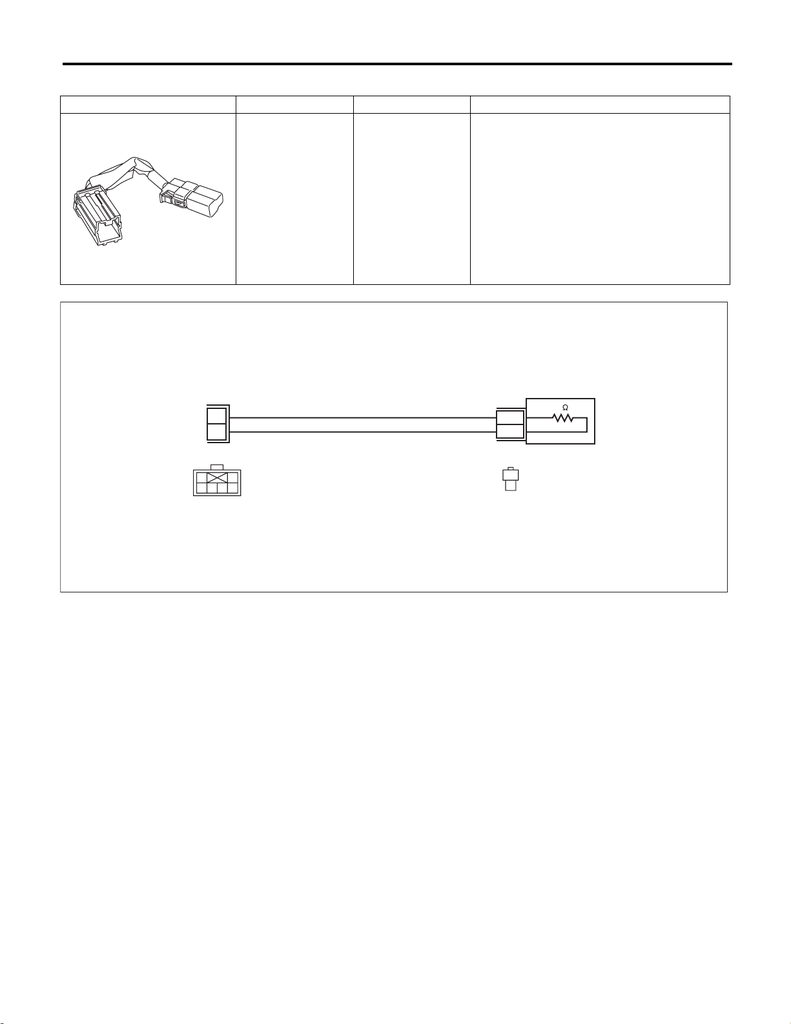

• AIRBAG RESISTOR

ILLUSTRATION TOOL NUMBER DESCRIPTION REMARKS

98299PA040 AIRBAG RESISTOR Used in replacement of airbag module for which

resistance value is same as airbag module.

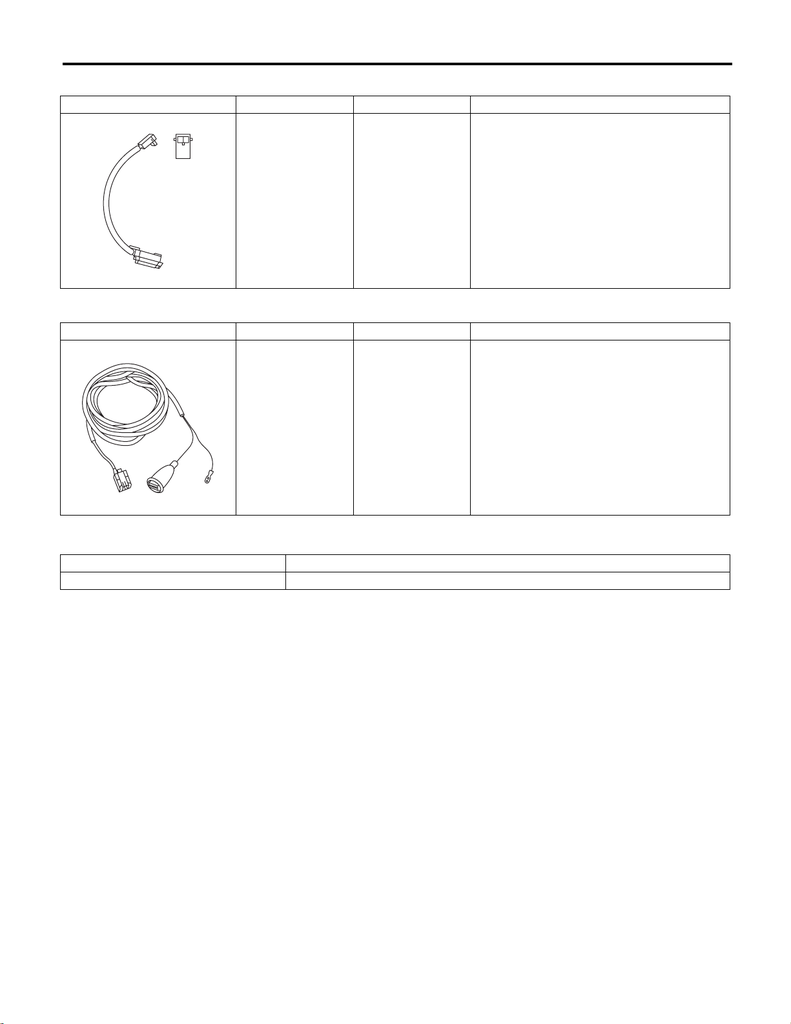

• TEST HARNESS ADAPTER D

• AIRBAG DEPLOYMENT TOOL

2. GENERAL TOOL

ILLUSTRATION TOOL NUMBER DESCRIPTION REMARKS

98299SA010 TEST HARNESS

ADAPTER D

• Used for operation process of pretensioner.

• Used together with AIRBAG DEPLOYMENT

TOOL. (98299PA030)

ILLUSTRATION TOOL NUMBER DESCRIPTION REMARKS

98299PA030 AIRBAG DEPLOY-

MENT TOOL

• Used for operation process of pretensioner.

• Used together with each test harness adapter.

TOOL NAME REMARKS

Circuit tester Used for measuring resistance and voltage.